# Programmieren in R: Abgabe 1

Gabriel Torres Gamez, Si Ben Tran, Patrick Schürmann

# Lineare und logistische Regressionen in R

Für die erste Abgabe im Modul PRR beschäftigen wir uns mit (multiplen) linearen und logistischen Regressionen. Diese Funktionen wenden wir auf den Datensatz “Carseats” an. Datensatz von ISRL2. Wir haben uns für diese Methoden entschieden, weil sie ein zentraler Bestandteil von Data Science sind. Sie wird verwendet, um Zusammenhängen in Datensätze zu verstehen und um Prognosen erstellen zu können. Diese Regressionen sind im R Grundpakte enthalten. Es muss also keine separate Library installiert und geladen werden.

Carseats ist ein **generischer** Datensatz, der im Buch “An Introduction to Statistical Learning” verwendet wird. Dieses Buch erarbeiten wir in diesem Studiengang im Modul “Statistisches Lernen”. Dort wird er zwar hauptsächlich angewendet um Decision Trees zu erstellen. Dank 11 Variablen und 400 Observationen eignet er sich aber auch gut für Regressionen. Jede Zeile im Datensatz entspricht einem Verkaufslokal, gejoint mit Durchschnittsstatitistiken für das Einzugsgebiet des Lokals. Für eine genau Erklärung der Variablen verweisen wir auf die Homepage https://rdrr.io/cran/ISLR2/man/Carseats.html. Für die unten stehenden Hypothesen werden wir mit folgenden Variablen arbeiten:

- Sales: Verkaufte Anzahl Kindersitze pro Standort in 1’000 Stück
- CompPrice: Verkaufte Anzahl Kindersitze von Konkurrenten in 1’000 Stück
- Income: Das Lohnniveau der Einzugsgebiete der Standorte in 1’000 Dollar
- Advertising: Lokale Marketingausgaben in 1’000 Dollar
- Population: Bevölkerungsgrösse der Standorte in 1’000 Personen
- CompPrice: Die Preise für Kindersitze der lokalen Konkurrenten
- Price: Preis pro Kindersitz an den Standorten
- ShelveLoc: Ein Faktor der die Qualität des Produktes einteilt
- Age: Durchschnittsalter der lokalen Bevölkerung
- Education: Bildungslevel an jedem Standort
- Urban: Klassifikation, ob sich der Standort in einer städtischen oder ländlichen Region befindet
- US: Ein Indikator der angibt, ob sich das Geschäft in US befindet oder nicht

# Lineare Regression

Bei der Linearen Regression versucht man eine Zielvariable in Abhängigkeit durch **eine** andere Variable vorherzusagen. Das daraus entstehende Modell wird als eine Gerade dargestellt mit der

Formel: y = f(x) = ax + b = $\beta_{0}$ + $\beta_{1}$x = mx + n

Das Wissen wird immersiv durch die Module llr, mlr und stl abgedeckt.

# Lineare Multiple Regression

Bei der Linearen Multiple Regression versucht man eine Zielvariable in Abhängigkeit durch **mehrere** andere Variable vorherzusagen.

Formel ausgeschrieben: y = f(X) = $\beta_{0}$ + $\beta_{1}$ $x_{1}$ + $\beta_{2}$ $x_{2}$ + … + $\beta_{n}$ $x_{n}$

Formel vektorisiert: y = f(X) = X $\cdot$ $\vec{\beta_{n}}$ + $\beta_{0}$

Das Wissen wird immersiv durch die Module llr, mlr und stl abgedeckt.

# Logistische Regression

Bei der Logistischen Regression versucht man eine Binäre Zielvariable in Abhängigkeit durch **eine** andere Variable vorherzusagen.

Sigmoid Formel: $\sigma(z) = \frac{1}{1 + e^{-z}}$

Formel fuer logistische Regression: f(x) = $\sigma(ax + b)$ = $\frac{1}{1 + e^{-(ax + b)}}$

Das Wissen wird immersiv durch die Module llr, mlr und stl abgedeckt.

# Auflistung der Hypothesen

Zur Analyse des Datensatzes haben wir uns folgende Fragen gestellt:

1. Sales ist abhängig von Income/Advertising/Population. (Lineare Regression)
2. Die Differenz von Comprice und Price hat einen Einfluss auf den Verkauf. (Lineare Regression)
3. Sales lässt sich durch die Verwendung von mehreren Features zuverlässiger vorhersagen. (Multiple Lineare Regression)
4. Bewohner von urbanen Regionen kaufen weniger Kindersitze als Bürger ländlicher Regionen.

# Vorbereitung

In diesem Kapitel installieren wir die notwendigen Libraries und verschaffen uns einen Überlick über den Carseats Datensatz.

## Installationen

```r
# Libraries installieren und laden
library(ISLR2)
library(tidyverse)
```

In der Library ISLR2 befindet sich der Datensatz. Tidyverse wird für die Darstellung des Datensatzes und Visualisierungen benötigt.

## Überblick Datensatz Carseats

In einem ersten Schritt ist es wichtig den Datensatz zu verstehen, bevor Visualisierungen und Modelle erstellt werden.

### Daten einlesen

```r
# Carseats Daten einlesen
data(Carseats)
```

### Kopfzeile Carseats ausgeben

```r
# Die ersten 6 Oberservationen ausgeben
head(Carseats)
```

```
##   Sales CompPrice Income Advertising Population Price ShelveLoc Age Education
## 1  9.50       138     73          11        276   120       Bad  42        17
## 2 11.22       111     48          16        260    83      Good  65        10
## 3 10.06       113     35          10        269    80    Medium  59        12
## 4  7.40       117    100           4        466    97    Medium  55        14
## 5  4.15       141     64           3        340   128       Bad  38        13
## 6 10.81       124    113          13        501    72       Bad  78        16
##   Urban  US
## 1   Yes Yes
## 2   Yes Yes
## 3   Yes Yes
## 4   Yes Yes
## 5   Yes  No
## 6    No Yes
```

### Selektieren von Spalten nach bestimmten Reihenfolgen

```r
Carseats <- Carseats %>% select(Sales, Price, CompPrice, Advertising, ShelveLoc, Urban, US,
                    Population, Income, Age, Education,)
```

### Fusszeile des Datensatzes ausgeben

```r
# Die letzten 6 Observationen ausgeben
tail(Carseats)
```

```
##     Sales Price CompPrice Advertising ShelveLoc Urban  US Population Income Age
## 395  5.35   139       130          19       Bad   Yes Yes        366     58  33
## 396 12.57   128       138          17      Good   Yes Yes        203    108  33
## 397  6.14   120       139           3    Medium    No Yes         37     23  55
## 398  7.41   159       162          12    Medium   Yes Yes        368     26  40
## 399  5.94    95       100           7       Bad   Yes Yes        284     79  50
## 400  9.71   120       134           0      Good   Yes Yes         27     37  49
##     Education
## 395        16
## 396        14
## 397        11
## 398        18
## 399        12
## 400        16
```

Durch die Ausgabe von Kopfzeile und Fusszeile kommen wir mit dem Datensatz in Berührung und koennen ein Bild der Attribute sowie Observationen machen.

### Informationen zum Datensatz herausfinden

```r
# Informationen zum DataFrame ausgeben
str(Carseats)
```

```
## 'data.frame':    400 obs. of  11 variables:
##  $ Sales      : num  9.5 11.22 10.06 7.4 4.15 ...
##  $ Price      : num  120 83 80 97 128 72 108 120 124 124 ...
##  $ CompPrice  : num  138 111 113 117 141 124 115 136 132 132 ...
##  $ Advertising: num  11 16 10 4 3 13 0 15 0 0 ...
##  $ ShelveLoc  : Factor w/ 3 levels "Bad","Good","Medium": 1 2 3 3 1 1 3 2 3 3 ...
##  $ Urban      : Factor w/ 2 levels "No","Yes": 2 2 2 2 2 1 2 2 1 1 ...
##  $ US         : Factor w/ 2 levels "No","Yes": 2 2 2 2 1 2 1 2 1 2 ...
##  $ Population : num  276 260 269 466 340 501 45 425 108 131 ...
##  $ Income     : num  73 48 35 100 64 113 105 81 110 113 ...
##  $ Age        : num  42 65 59 55 38 78 71 67 76 76 ...
##  $ Education  : num  17 10 12 14 13 16 15 10 10 17 ...
```

Durch str wird und die grösse des DataFrames angezeigt sowie die anzahl an Features (Spalten). Weiter erkennen wir von jeder Spalte den Datenyp. Weiter erkennen wir auch einige Werte die in der Spalte vorkommen.

### Reihenfolge von ShelveLoc definieren

```r
Carseats$ShelveLoc <- factor(Carseats$ShelveLoc, ordered = TRUE, levels = c("Good", "Medium", "Bad"))
```

### Summarische Zusammenfassung von Carseats

```r
# Statistische Kennzahlen
summary(Carseats)
```

```
##      Sales            Price         CompPrice    Advertising      ShelveLoc
##  Min.   : 0.000   Min.   : 24.0   Min.   : 77   Min.   : 0.000   Good  : 85
##  1st Qu.: 5.390   1st Qu.:100.0   1st Qu.:115   1st Qu.: 0.000   Medium:219
##  Median : 7.490   Median :117.0   Median :125   Median : 5.000   Bad   : 96
##  Mean   : 7.496   Mean   :115.8   Mean   :125   Mean   : 6.635
##  3rd Qu.: 9.320   3rd Qu.:131.0   3rd Qu.:135   3rd Qu.:12.000
##  Max.   :16.270   Max.   :191.0   Max.   :175   Max.   :29.000
##  Urban       US        Population        Income            Age
##  No :118   No :142   Min.   : 10.0   Min.   : 21.00   Min.   :25.00
##  Yes:282   Yes:258   1st Qu.:139.0   1st Qu.: 42.75   1st Qu.:39.75
##                      Median :272.0   Median : 69.00   Median :54.50
##                      Mean   :264.8   Mean   : 68.66   Mean   :53.32
##                      3rd Qu.:398.5   3rd Qu.: 91.00   3rd Qu.:66.00
##                      Max.   :509.0   Max.   :120.00   Max.   :80.00
##    Education
##  Min.   :10.0
##  1st Qu.:12.0
##  Median :14.0
##  Mean   :13.9
##  3rd Qu.:16.0
##  Max.   :18.0
```

wir geben von jeder numerischen Spalte die summarischen Statistiken aus. Darin enthalten sind: Minimum, 1. Quantil, Median, Mittelwert, 3. Quantil, Maximum. Im summary() werden auch die Anzahl fehlende Werte angezeigt. In unserem Fall besitzt der Datensatz keine fehlende Werte. Die Aufbereitung der Daten entfällt deshalb.

### Visualisierung der Daten

#### Verteilung der Sales

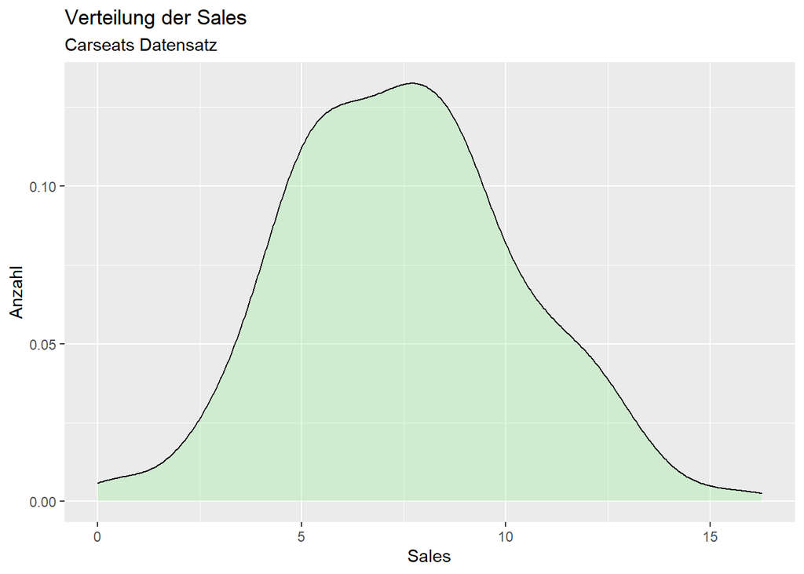

```r
ggplot(data = Carseats, aes(x = Sales)) +
  geom_density(fill = "lightgreen", color = "black", alpha = 0.3) +
  labs(x = "Sales",
       y = "Anzahl",
       title = "Verteilung der Sales",
       subtitle = "Carseats Datensatz")
```

Hier in diesem Dichte-Diagramm erkennen wir die Verteilung der numerischen Variabel Sales. Die y Achse ist die Wahrscheinlichkeit für das Auftreten einer numerischen Sales Variabel. Aus diesem Grund wird die Dichtefunktion auch oft Wahrscheinlichkeitsdichtefunktion genannt. Sie ist eine gegelättete Version des Histogramm und wird oft nach dem gleichen Konzept verwendet.

#### Verteilung der Sales anhand der Variable Urban

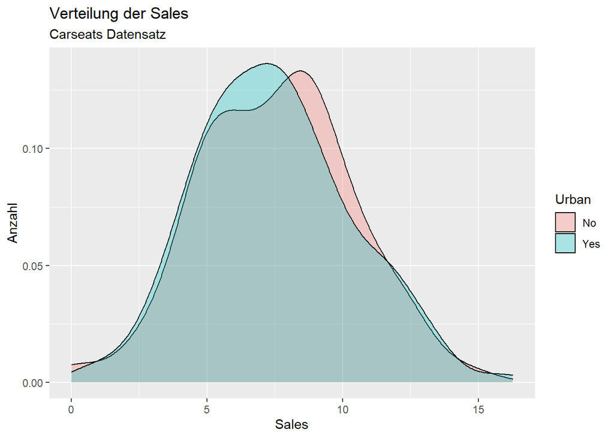

```r
ggplot(data = Carseats, aes(x = Sales, fill = Urban)) +
  geom_density(alpha = 0.3) +
  labs(x = "Sales",
       y = "Anzahl",
       title = "Verteilung der Sales",
       subtitle = "Carseats Datensatz")
```

#### Multiplots Verteilungen von Sales

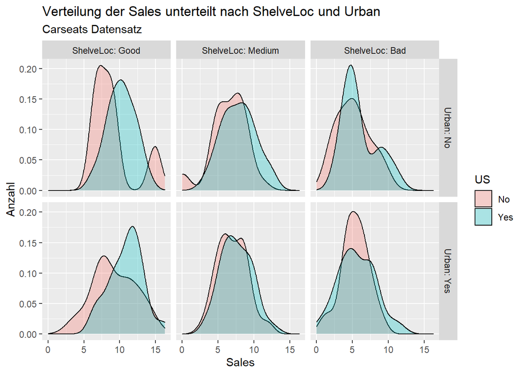

```r
ggplot(Carseats, aes(x = Sales, fill = US)) +
  geom_density(alpha = 0.3) +
  facet_grid(Urban  ~ ShelveLoc, labeller = label_both) +
  labs(x = "Sales",
       y = "Anzahl",
       title = "Verteilung der Sales unterteilt nach ShelveLoc und Urban",
       subtitle = "Carseats Datensatz")
```

In diesem Multiplot unterteilen wir die Dichteverteilung nach weiteren Kategorien, wie Urban und ShelveLoc. Auch unterteilen wir farblich, ob sich das Geschaeft in den US befindet oder nicht, damit wir ein Gefuehl fuer die Sales Verteilung mit verschiedenen Kategorischen Werten kriegen. Aufaellig ist, dass die Verteilungen bei ShelveLoc Bad deutlich weiter Links sind (Mittelwert tiefer als bei ShelveLoc Medium und Good). Auch erkennen wir bei ShelveLoc Good, das die Kindersitze in den nicht US laendern weniger verkauft werden als in den US selber.

#### Multiplots Verteilungen von Price

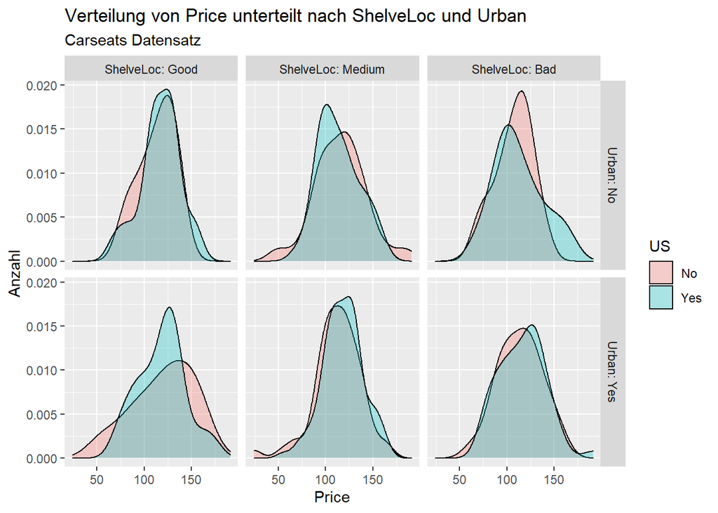

```r
ggplot(Carseats, aes(x = Price, fill = US)) +
  geom_density(alpha = 0.3) +
  facet_grid(Urban  ~ ShelveLoc, labeller = label_both) +
  labs(x = "Price",
       y = "Anzahl",
       title = "Verteilung von Price unterteilt nach ShelveLoc und Urban",
       subtitle = "Carseats Datensatz")
```

# Hypothese 1: Sales ist abhängig von Income/Advertising/Population der Region.

Thema: Einfache lineare Regression

## Sales vs. Income

### Visualisierung von Sales und Income

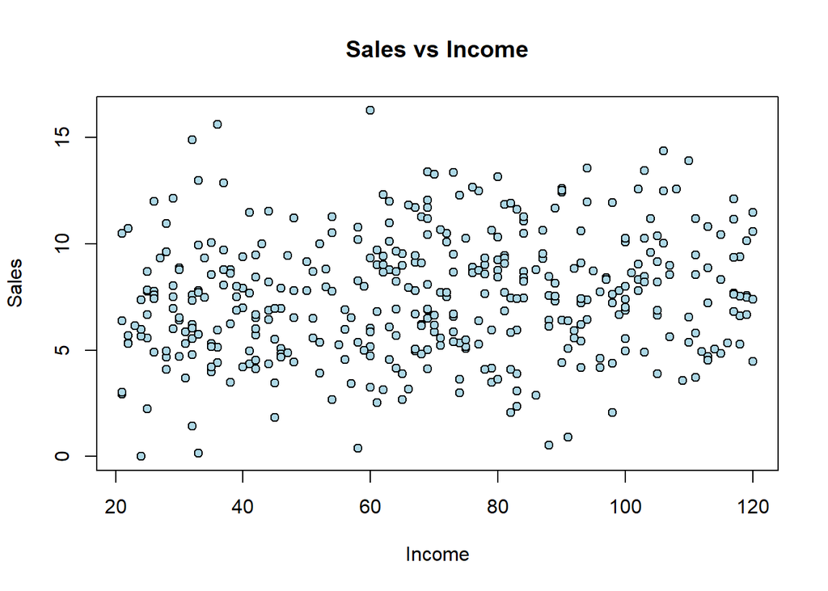

```r
plot(Sales ~ Income, data = Carseats,
     main = "Sales vs Income", pch=21, bg = "lightblue")
```

Bevor wir mit der Linearen Regression beginnen, erstellen wir zuerst ein Streudiagramm von beiden Variabeln, um die Zusammenhaenge zu visualiseren. Hier erkennen wir im Plot, dass die Variabeln Einkommen und Sales nicht besonders stark korrelieren, da die Punkte ueberall im Plot verstreut sind.

### Modell erstellen

```r
lm.fit1 <- lm(Sales ~ Income, data = Carseats)
```

Mit der Funktion “lm()” wird das Lineare Modell erstellt und trainiert.

### Auswertung vom Modell

```r
summary(lm.fit1)
```

```
##
## Call:
## lm(formula = Sales ~ Income, data = Carseats)
##
## Residuals:
##     Min      1Q  Median      3Q     Max
## -7.2629 -1.9447 -0.1772  1.7654  8.9064
##
## Coefficients:
##             Estimate Std. Error t value Pr(>|t|)
## (Intercept)  6.44356    0.37061  17.386  < 2e-16 ***
## Income       0.01533    0.00500   3.067  0.00231 **
## ---
## Signif. codes:  0 '***' 0.001 '**' 0.01 '*' 0.05 '.' 0.1 ' ' 1
##
## Residual standard error: 2.795 on 398 degrees of freedom
## Multiple R-squared:  0.02309,    Adjusted R-squared:  0.02063
## F-statistic: 9.407 on 1 and 398 DF,  p-value: 0.00231
```

R hat nun die linear Regression erstellt. Die wichtigsten Werte lassen sich mit der Methode summary() anzeigen.Der Intercept beträgt 6.44 und die Steigung 0.015. Pro 1’000 Dollar höheres Einkommen steigt der Verkauf um 15 Stück. Dies erscheint im Verhältnis zum Intercept wenig, es müsste darüber diskutiert werden, ob dieser Erkenntnis für einen möglichen Kunden aussagekräftig ist.Anhand vom P Wert (0.00231) lässt sich aber feststellen, dass die Steigung siginfikant ist. Das Einkommen der Region hat also einen Einfluss auf die Verkaufszahlen. Vor einer endültigen Aussage müssen aber weitere Untersuchungen, wie die Überprüfung der Residuen, durchgeführt werden. Diese Untersuchung führen wir später durch.

### Übersicht der Modell Methoden

```r
names(lm.fit1)
```

```
##  [1] "coefficients"  "residuals"     "effects"       "rank"
##  [5] "fitted.values" "assign"        "qr"            "df.residual"
##  [9] "xlevels"       "call"          "terms"         "model"
```

Das Modell enthält weitere Berechnungen und Kennzahlen. Names() zeigt eine Übersicht dieser Methoden.

### Koeffzienten vom Modell ausgeben

```r
lm.fit1$coefficients
```

```
## (Intercept)      Income
##  6.44355748  0.01533361
```

Die oben ersichtlichen Koeffizienten lassen sich direkt via $coefficients abrufen.

### Konfidenzintervall für Koeffizienten angeben

```r
confint(lm.fit1)
```

```
##                   2.5 %     97.5 %
## (Intercept) 5.714962797 7.17215216
## Income      0.005504876 0.02516235
```

Wertvoll ist die Berechnung der Konfidenzintervalle, die im Summary nicht angezeigt wird. Diese gibt an, in welchem Bereich sich die Koeffizienten mit einer Wahrscheinlichkeit von 95% befinden.

### Visualisierung der Daten mit dem Regressions Modell (Visualsierung ausbessern)

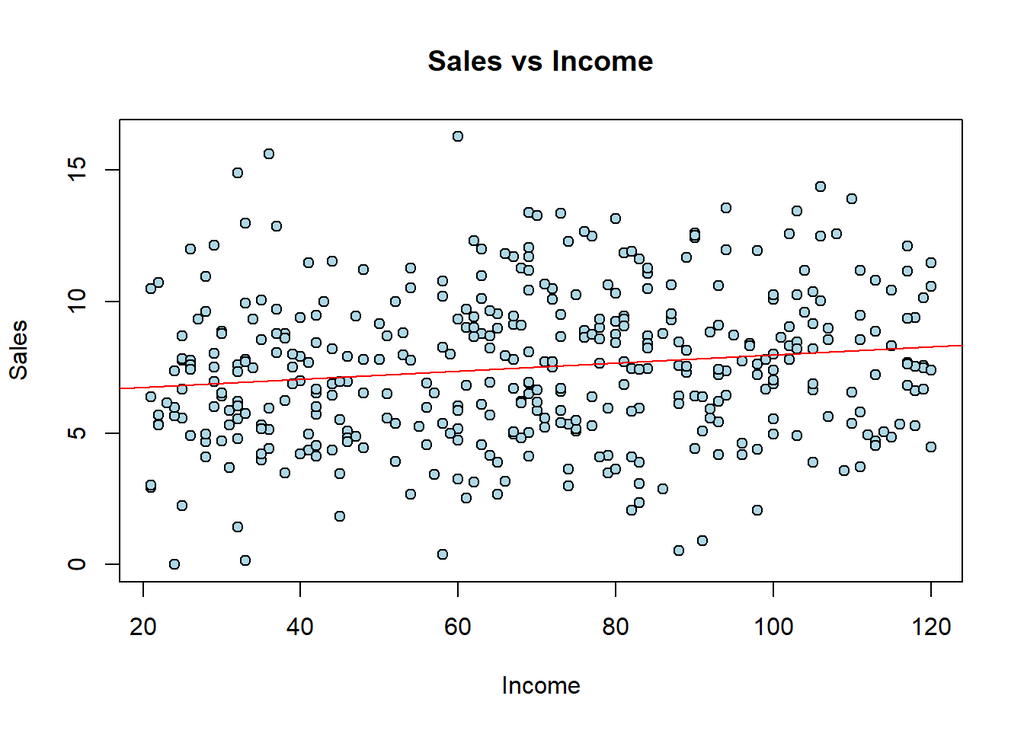

```r
plot(Sales ~ Income, data = Carseats,
     main = "Sales vs Income", pch=21, bg = "lightblue")

abline(lm.fit1, col = "red")
```

Das Modell lässt sich direkt mit der Plotfunktion darstellen. Mit abline() lassen sich Linien zeichnen, in diesem Fall die lineare Regression. Im Plot erkennen wir, dass Income und Sales eine Punktwolke bilden. Sales streut auf der ganzen X Achse von maximalen bis minimalen beobaachteten Wert (0 - 15). Entsprechend korrelieren beide Variabeln wenig miteinander. Es gibt keinen klaren Zusammenhang.

### Residuenanalyse

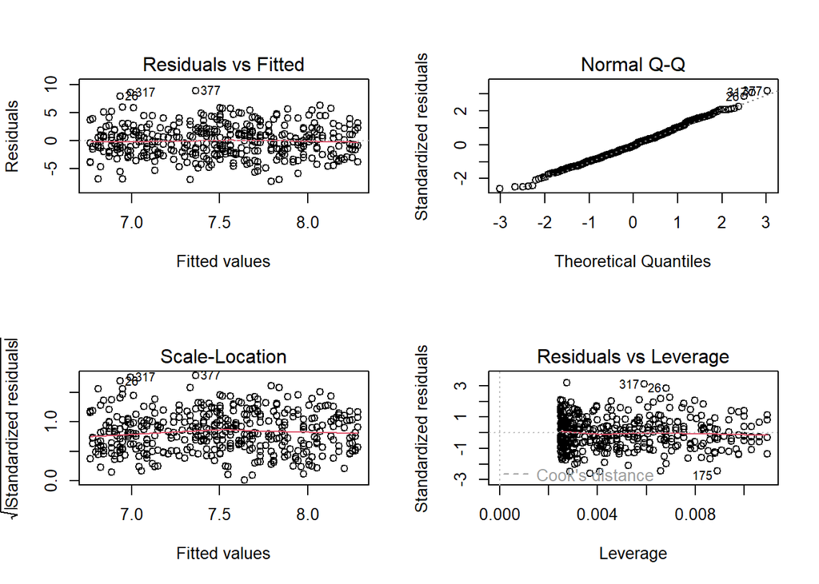

```r
par(mfrow = c(2, 2))
plot(lm.fit1)
```

Nun, da wir unser Modell haben, können wir feststellen, ob es ein gutes Modell ist, indem wir bei den Residuen folgende 3 Bedingungen überprüfen:

- Der Fehler sollte nicht abhängig sein
- Der Erwartungswert sollte bei 0 liegen.
- Die Residuen sollten einer Normalverteilung folgen

Das mittlere Kriterium lässt sich aus der Summary Funktion ablesen. Der Median der Residuen entspricht -0.18, dieses Kriterium ist erfüllt.

Auch dafür bietet R einfache Möglichkeiten an. Mit der folgenden beiden Funktionen lassen sich vier unterschiedliche Überprüfungen der Residuen anzeigen.

Im ersten Plot oben links (Tukeyanscombe Plot) wird ersichtich, dass die Residuen/Fehler unabhängig von einander sind und nicht keinem Muster folgen. Auch dieses Kriterium ist somit erfüllt.

Die Verteilung der Residuen lässt sich einfach im Histogramm überprüfen, ob deren Mittelwert sich um 0 Verteilt.

Ueberpreufen vom Erwartungswert = 0 und Normalverteilt:

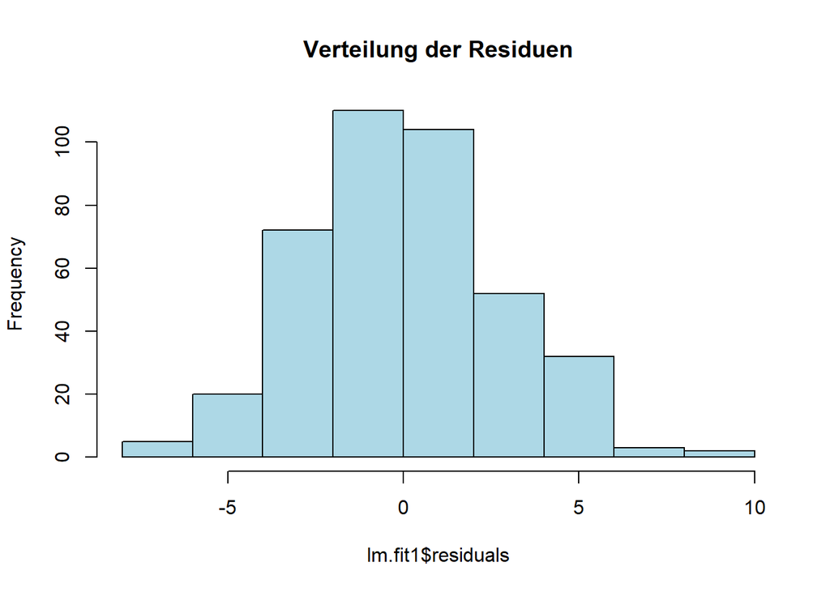

```r
hist(lm.fit1$residuals,
     main = "Verteilung der Residuen", col = "lightblue")
```

### Interpretation

Hypothese: Sales ist abhängig von Income?

Wir erkennen aufgrund des Streudiagramm, dass eine Korrelation zwischen einkommen und Sales kaum vorhanden sind. Das Lineare Modell hat einen R^2 von 0.02, dies bestaetigt die Aussage.

## Sales vs. Population

### Visualisierung von Sales und Population

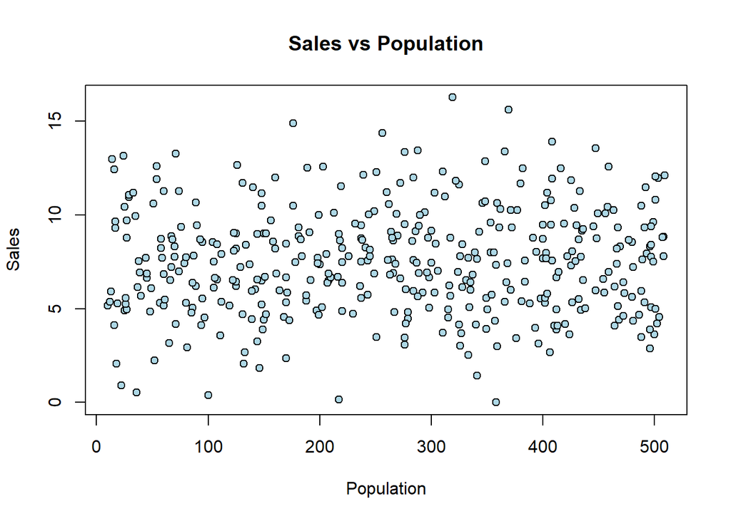

```r
plot(Sales ~ Population, data = Carseats,
     main = "Sales vs Population", pch=21, bg = "lightblue")
```

Bevor das Modell erstellt wird, visualisieren wir die beiden Variabeln Population und Sales in eine Streudiagramm.

### Model erstellen und Auswertung

```r
lm.fit2 <- lm(Sales ~ Population, data = Carseats)
summary(lm.fit2)
```

```
##
## Call:
## lm(formula = Sales ~ Population, data = Carseats)
##
## Residuals:
##     Min      1Q  Median      3Q     Max
## -7.5864 -2.0176 -0.0597  1.6892  8.7213
##
## Coefficients:
##              Estimate Std. Error t value Pr(>|t|)
## (Intercept) 7.2401837  0.2906658  24.909   <2e-16 ***
## Population  0.0009672  0.0009593   1.008    0.314
## ---
## Signif. codes:  0 '***' 0.001 '**' 0.01 '*' 0.05 '.' 0.1 ' ' 1
##
## Residual standard error: 2.824 on 398 degrees of freedom
## Multiple R-squared:  0.002547,   Adjusted R-squared:  4.116e-05
## F-statistic: 1.016 on 1 and 398 DF,  p-value: 0.314
```

### Visualisierung der Daten mit dem Regressions Modell (Visualsierung ausbessern)

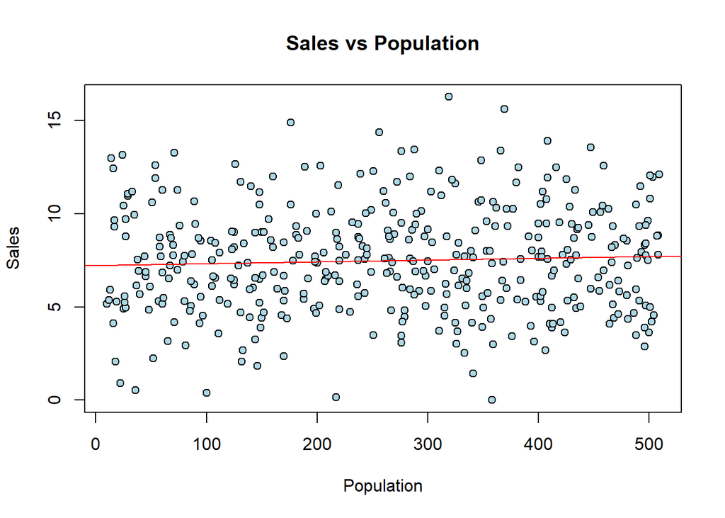

```r
plot(Sales ~ Population, data = Carseats,
     main = "Sales vs Population", pch=21, bg = "lightblue")
abline(lm.fit2, col = "red")
```

Hier in diesem Plot stellen wir die Population mit Sales sowie dem Modell zusammen. Wir erkennen, dass die Punkte sich deutlich von der roten Linie (Model) streuen. Das Problem besteht analog zu Sales und Income.

### Residuenanalyse

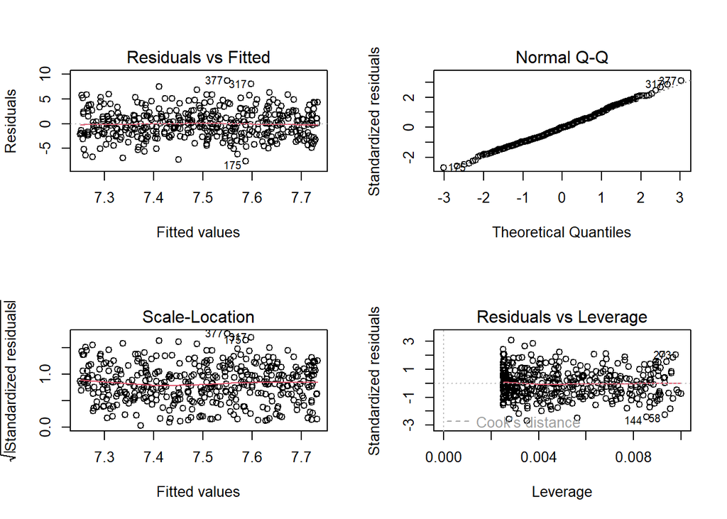

```r
par(mfrow = c(2, 2))
plot(lm.fit2)
```

Auch in diesem Model ueberpruefen wir die folgenden Kriterien des Models.

- Der Fehler sollte nicht abhängig sein
- Der Erwartungswert sollte bei 0 liegen.
- Die Residuen sollten einer Normalverteilung folgen

Das mittlere Kriterium lässt sich aus der Summary Funktion ablesen. Der Median der Residuen entspricht -0.0597, dieses Kriterium ist erfüllt.

Auch dafür bietet R einfache Möglichkeiten an. Mit der folgenden beiden Funktionen lassen sich vier unterschiedliche Überprüfungen der Residuen anzeigen.

Im ersten Plot oben links (Tukeyanscombe Plot) wird ersichtich, dass die Residuen/Fehler unabhängig von einander sind und nicht keinem Muster folgen. Auch dieses Kriterium ist somit erfüllt.

Die Verteilung der Residuen lässt sich einfach im Histogramm überprüfen, ob deren Mittelwert sich um 0 Verteilt.

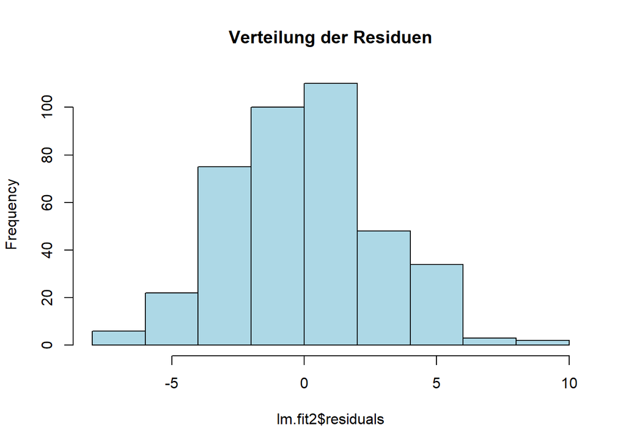

```r
hist(lm.fit2$residuals,
     main = "Verteilung der Residuen", col = "lightblue")
```

### Interpretation

Hypothese: Sales ist abhängig von Population?

Leider auch hier, aehnlich wie zu Sales vs. Income erkennen wir keinen Trend. Der R^2 Score betraegt 0.002547, also auch kein Gutes Modell.

Aus diesem Grund, stimmt auch diese Hypothese nicht.

## Sales vs. Advertising

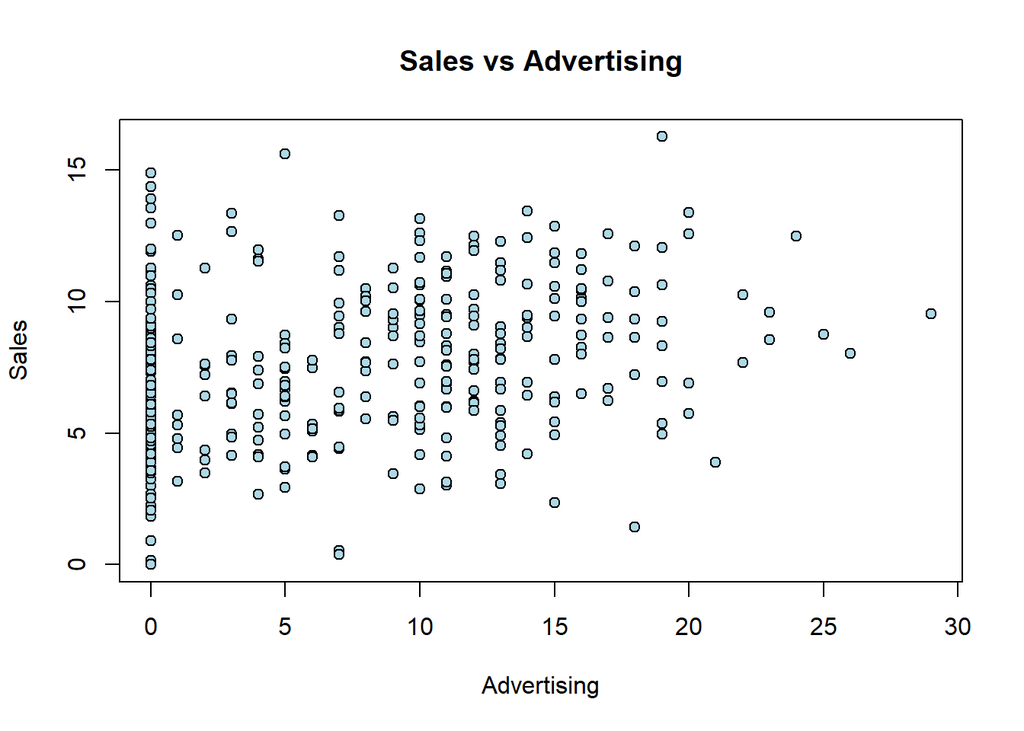

```r
plot(Sales ~ Advertising, data = Carseats,
     main = "Sales vs Advertising", pch=21, bg = "lightblue")
```

Bevor das Modell erstellt wird, visualisieren wir die beiden Variabeln Advertising und Sales.

### Modell erstellen und Auswertung

```r
lm.fit3 <- lm(Sales ~ Advertising, data = Carseats)
summary(lm.fit3)
```

```
##
## Call:
## lm(formula = Sales ~ Advertising, data = Carseats)
##
## Residuals:
##     Min      1Q  Median      3Q     Max
## -7.3770 -1.9634 -0.1037  1.7222  8.3208
##
## Coefficients:
##             Estimate Std. Error t value Pr(>|t|)
## (Intercept)   6.7370     0.1925  35.007  < 2e-16 ***
## Advertising   0.1144     0.0205   5.583 4.38e-08 ***
## ---
## Signif. codes:  0 '***' 0.001 '**' 0.01 '*' 0.05 '.' 0.1 ' ' 1
##
## Residual standard error: 2.723 on 398 degrees of freedom
## Multiple R-squared:  0.07263,    Adjusted R-squared:  0.0703
## F-statistic: 31.17 on 1 and 398 DF,  p-value: 4.378e-08
```

### Visualisierung der Daten mit dem Regressions Modell

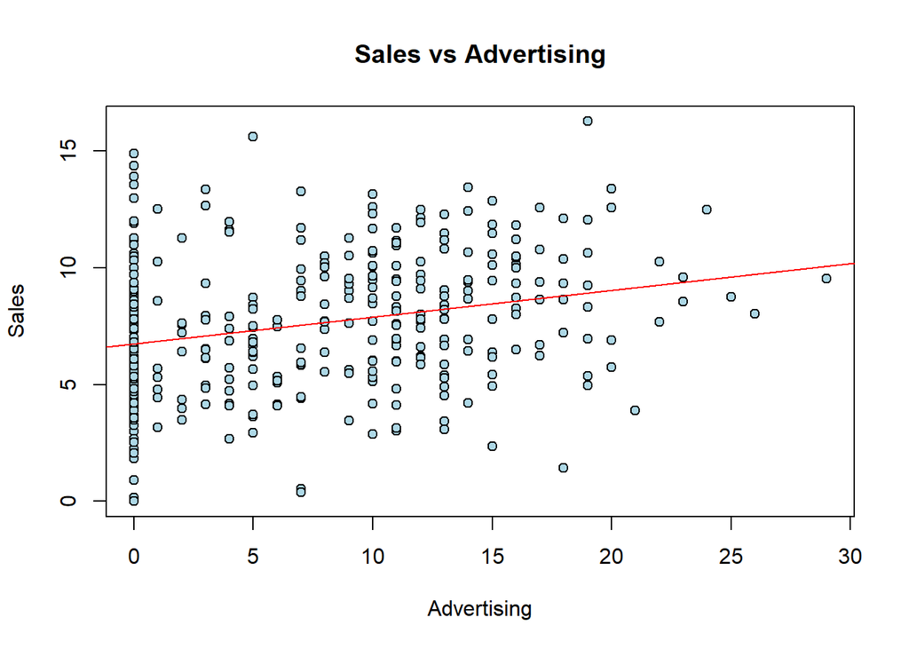

```r
plot(Sales ~ Advertising, data = Carseats,
     main = "Sales vs Advertising", pch=21, bg = "lightblue")
abline(lm.fit3, col = "red")
```

### Residuenanalyse

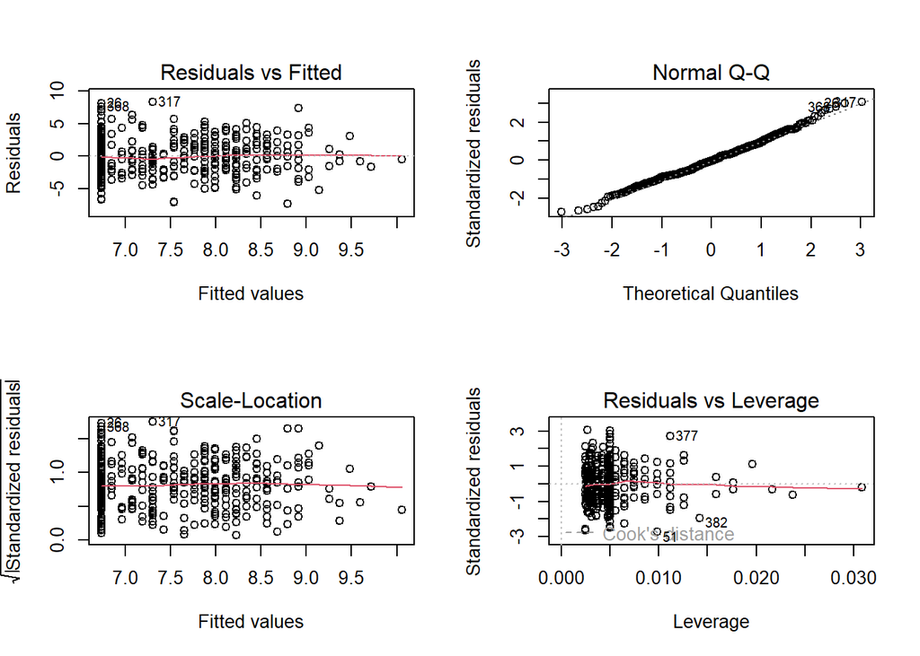

```r
par(mfrow = c(2, 2))
plot(lm.fit3)
```

Auch in diesem Model ueberpruefen wir die folgenden Kriterien des Models.

- Der Fehler sollte nicht abhängig sein
- Der Erwartungswert sollte bei 0 liegen.
- Die Residuen sollten einer Normalverteilung folgen

Das mittlere Kriterium lässt sich aus der Summary Funktion ablesen. Der Median der Residuen entspricht -0.1037, dieses Kriterium ist erfüllt.

Auch dafür bietet R einfache Möglichkeiten an. Mit der folgenden beiden Funktionen lassen sich vier unterschiedliche Überprüfungen der Residuen anzeigen.

Im ersten Plot oben links (Tukeyanscombe Plot) wird ersichtich, dass die Residuen/Fehler unabhängig von einander sind und nicht keinem Muster folgen. Auch dieses Kriterium ist somit erfüllt.

Die Verteilung der Residuen lässt sich einfach im Histogramm überprüfen, ob deren Mittelwert sich um 0 Verteilt.

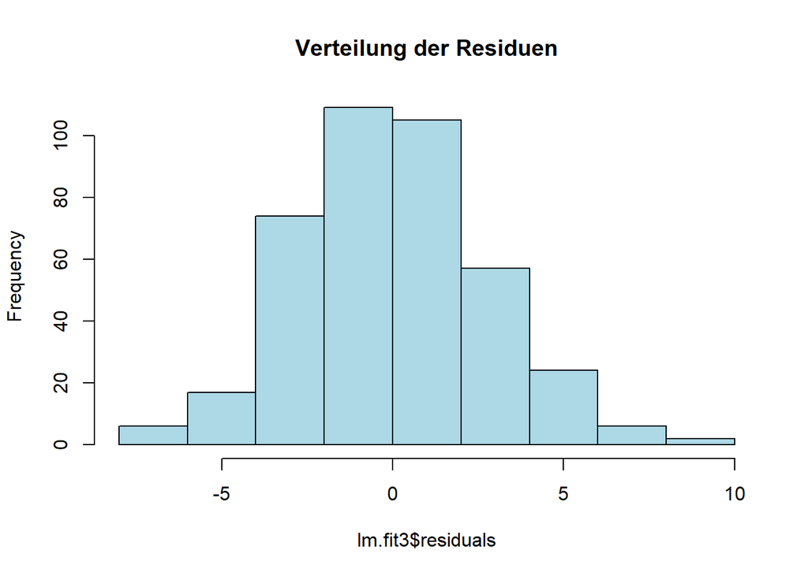

```r
hist(lm.fit3$residuals,
     main = "Verteilung der Residuen", col = "lightblue")
```

### Interpretation

Hypothese: Sales ist abhängig von Advertising?

# Hypothese 2: Die Differenz von Comprice und Price hat einen Einfluss auf den Verkauf.

Thema: Einfach lineare Regression mit berechneten Daten

## Sales vs. Preisdifferenz zu Konkurrenz

### Berechnung der Spalte DiffPrice

Hinzufügen einer Spalte mit der Differenz zwischen unserem Preis und der der Konkurrenz.

```r
Carseats <- Carseats %>% mutate(DiffPrice = Price - CompPrice)
str(Carseats)
```

```
## 'data.frame':    400 obs. of  12 variables:
##  $ Sales      : num  9.5 11.22 10.06 7.4 4.15 ...
##  $ Price      : num  120 83 80 97 128 72 108 120 124 124 ...
##  $ CompPrice  : num  138 111 113 117 141 124 115 136 132 132 ...
##  $ Advertising: num  11 16 10 4 3 13 0 15 0 0 ...
##  $ ShelveLoc  : Ord.factor w/ 3 levels "Good"<"Medium"<..: 3 1 2 2 3 3 2 1 2 2 ...
##  $ Urban      : Factor w/ 2 levels "No","Yes": 2 2 2 2 2 1 2 2 1 1 ...
##  $ US         : Factor w/ 2 levels "No","Yes": 2 2 2 2 1 2 1 2 1 2 ...
##  $ Population : num  276 260 269 466 340 501 45 425 108 131 ...
##  $ Income     : num  73 48 35 100 64 113 105 81 110 113 ...
##  $ Age        : num  42 65 59 55 38 78 71 67 76 76 ...
##  $ Education  : num  17 10 12 14 13 16 15 10 10 17 ...
##  $ DiffPrice  : num  -18 -28 -33 -20 -13 -52 -7 -16 -8 -8 ...
```

### Visualisierung von Sales und DiffPrice

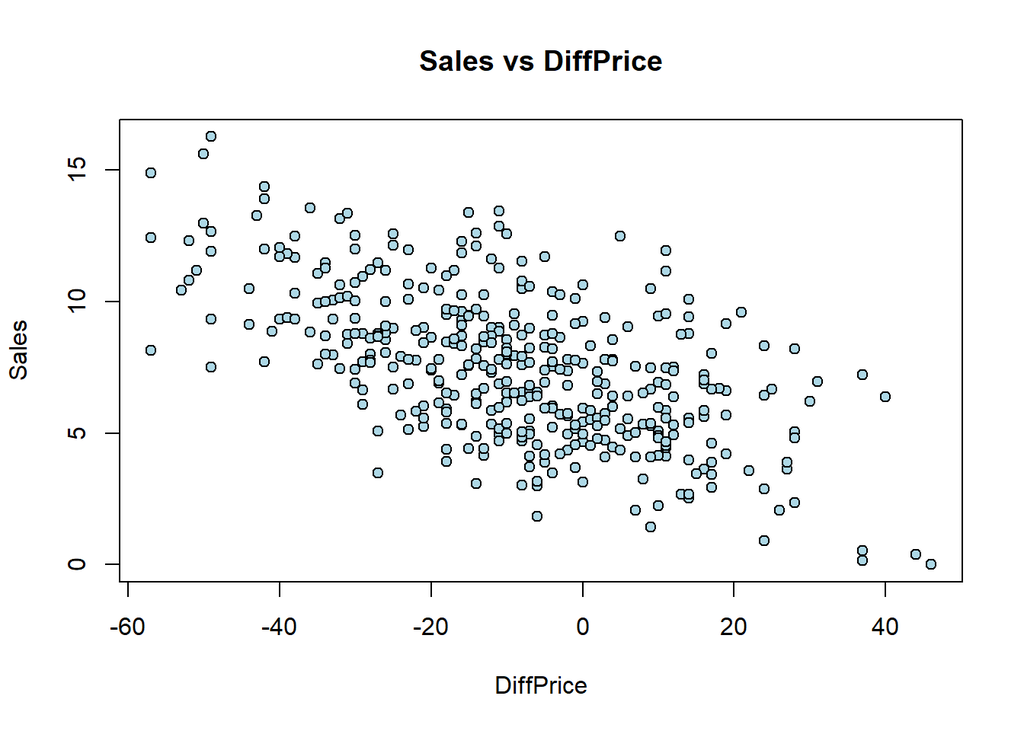

```r
plot(Sales ~ DiffPrice, data = Carseats,
     main = "Sales vs DiffPrice", pch=21, bg = "lightblue")
```

In dieser Visualisierung von DiffPrice und Sales erkennen wir, dass die Streupunkte einem gewissen Trend folgen.

### Model erstellen und Auswertung

```r
lm.fit4 <- lm(Sales ~ DiffPrice, data = Carseats)
summary(lm.fit4)
```

```
##
## Call:
## lm(formula = Sales ~ DiffPrice, data = Carseats)
##
## Residuals:
##     Min      1Q  Median      3Q     Max
## -5.5885 -1.6583 -0.2678  1.5394  6.2367
##
## Coefficients:
##              Estimate Std. Error t value Pr(>|t|)
## (Intercept)  6.691590   0.125567   53.29   <2e-16 ***
## DiffPrice   -0.087662   0.005891  -14.88   <2e-16 ***
## ---
## Signif. codes:  0 '***' 0.001 '**' 0.01 '*' 0.05 '.' 0.1 ' ' 1
##
## Residual standard error: 2.267 on 398 degrees of freedom
## Multiple R-squared:  0.3575, Adjusted R-squared:  0.3559
## F-statistic: 221.5 on 1 and 398 DF,  p-value: < 2.2e-16
```

Die Auswertung zeigt, dass dieses Modell einen R^2 von 0.3575 hat. Dies ist nicht besonders gut, dennoch besser als die ersten drei Modelle.

### Visualisierung der Daten mit dem Regressions Modell (Visualsierung ausbessern)

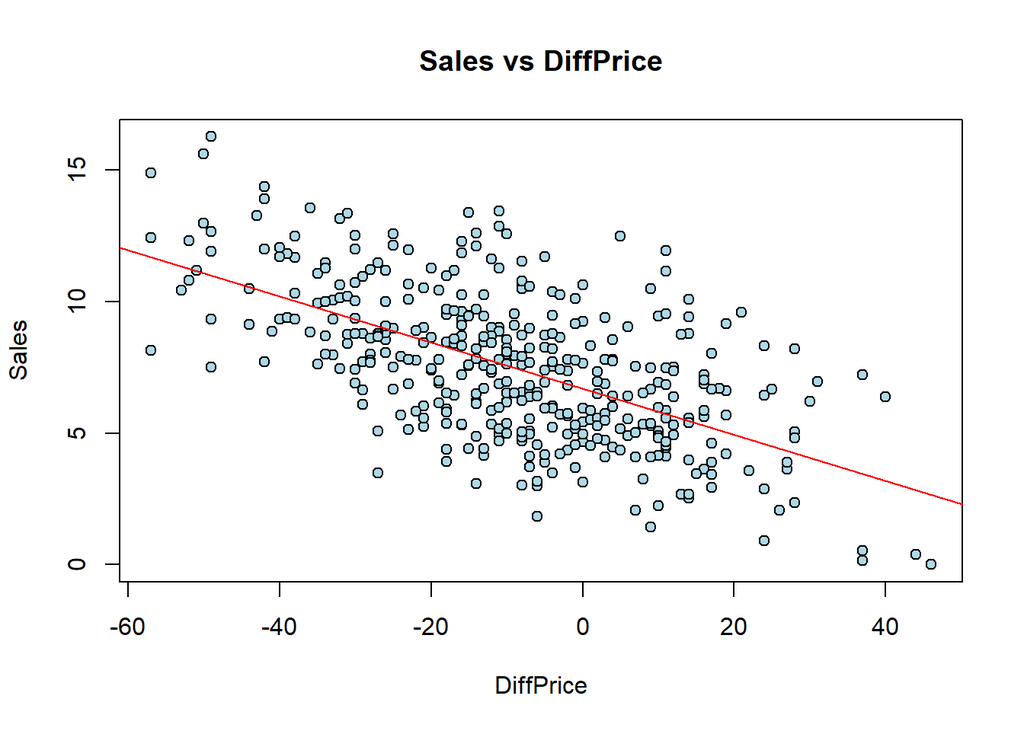

```r
plot(Sales ~ DiffPrice, data = Carseats,
     main = "Sales vs DiffPrice", pch=21, bg = "lightblue")
abline(lm.fit4, col = "red")
```

Hier in diesem Diagramm erkennen wir, dass das Modell eine negative Steigung hat. Dies erkennen wir einerseits an der Steigung im Summary, aber auch bei der Visualisierung.

### Residuenanalyse

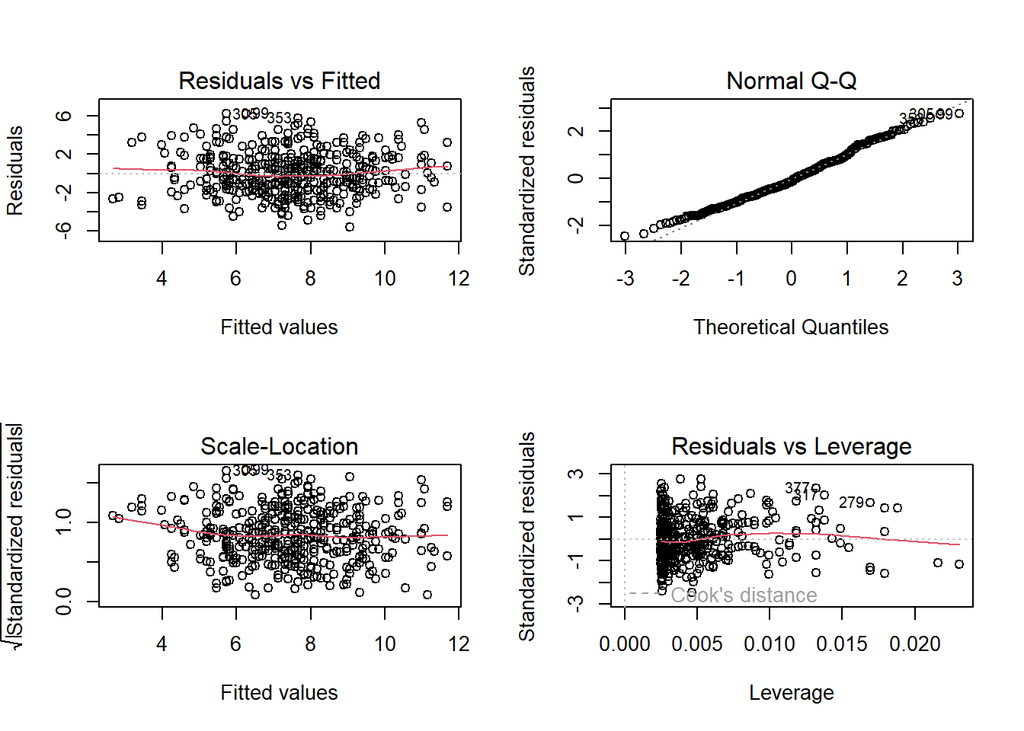

```r
par(mfrow = c(2, 2))
plot(lm.fit4)
```

Auch in diesem Modell ueberpruefen wir die folgenden Kriterien des Modells.

- Der Fehler sollten unabhängig sein.
- Der Erwartungswert sollte bei 0 liegen.
- Die Residuen sollten einer Normalverteilung folgen.

Das mittlere Kriterium lässt sich aus der Summary Funktion ablesen. Der Median der Residuen entspricht -0.2678, dieses Kriterium ist erfüllt.

Auch dafür bietet R einfache Möglichkeiten an. Mit der folgenden beiden Funktionen lassen sich vier unterschiedliche Überprüfungen der Residuen anzeigen.

Im ersten Plot oben links (Tukeyanscombe Plot) wird ersichtich, dass die Residuen/Fehler unabhängig von einander sind und nicht keinem Muster folgen. Auch dieses Kriterium ist somit erfüllt.

Die Verteilung der Residuen lässt sich einfach im Histogramm überprüfen, ob deren Mittelwert sich um 0 Verteilt.

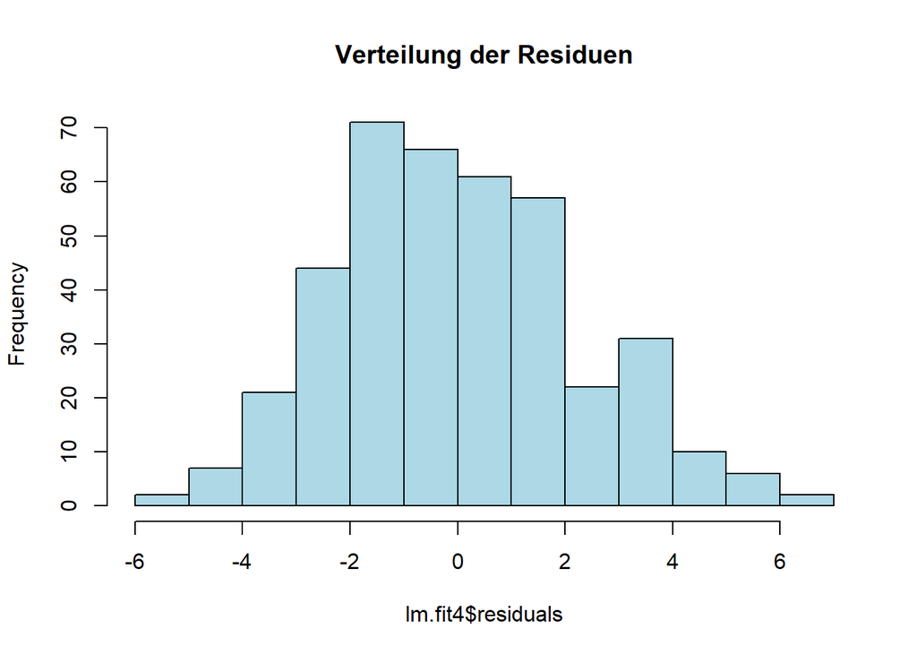

```r
hist(lm.fit4$residuals,
     main = "Verteilung der Residuen", col = "lightblue")
```

## Interpretation der Hypothese 2

Hypothese: Die Differenz von Comprice und Price hat einen Einfluss auf den Verkauf.

Die zweite Hypothese hat einen deutlich besseren R^2 Score verglichen zu den ersten drei Modellen bei der Hypothese 1. Die Differenz von Comprice und Price hat keinen grossen Einfluss auf Sales, weil das Bestimmtheitsmass 0.3575 betraegt.

Es ist interessant zu erkennen, dass der Preisunterschied zwischen der Konkurrenz und dem Produkt einen ganz leichten negativen Trend zeigt. Nichts destotrotz, sind wir mit diesem Modell nicht zufrieden und begeben uns direkt in die Hypothese 3.

# Hypothese 3: Sales lässt sich durch die Verwendung von mehreren Features zuverlässiger vorhersagen.

Thema: Multiple lineare Regression

## Sales vs. mehrere Features

Nachdem wir festgestellt haben, dass sich Sales nicht durch einzelne Variabeln erklären lasst, untersuchen wir die Möglichkeit, ob Sales sich durch mehrere Features erklaeren laesst. Wir werden sie zuerst gegenüber zwei Variabel untersuchen. Danach schauen wir uns den ganzen Datensatz an und behalten danach die aussagekräftigsten Variabeln.

### Modelle erstellen und Auswertungen

In diesem Kapitel erstellen wir mehrere Modelle und wählen eines aufgrund einer ersten Auswertung für die weitere Untersuchung aus.

#### Sales vs. Income und Population

```r
mlr.fit1 <- lm(Sales ~ Income + Population, data = Carseats)
summary(mlr.fit1)
```

```
##
## Call:
## lm(formula = Sales ~ Income + Population, data = Carseats)
##
## Residuals:
##     Min      1Q  Median      3Q     Max
## -7.0371 -1.9342 -0.1477  1.7786  8.8532
##
## Coefficients:
##              Estimate Std. Error t value Pr(>|t|)
## (Intercept) 6.1785056  0.4493283  13.751  < 2e-16 ***
## Income      0.0153747  0.0049991   3.075  0.00225 **
## Population  0.0009902  0.0009493   1.043  0.29757
## ---
## Signif. codes:  0 '***' 0.001 '**' 0.01 '*' 0.05 '.' 0.1 ' ' 1
##
## Residual standard error: 2.795 on 397 degrees of freedom
## Multiple R-squared:  0.02576,    Adjusted R-squared:  0.02085
## F-statistic: 5.248 on 2 and 397 DF,  p-value: 0.005627
```

Zuerst untersuchen wir Sales gegenüber Income und der Population. In der Auswertung wird ersichtlich, dass Population keinen Zusammenhang aufweist. R^2 spricht ebenfalls gegen einen Zusammenhang in dieser Auswertung.

Die F-Statistik sagt aus, dass mit hoher Wahrscheinlichkeit (p-Wert < 0.6%) mindestens eine Variabel einen Einfluss hat. In unserem Fall ist das Income, was wir schon aus vorhergehenden Modellen wissen.

#### Sales vs. Income und Population und deren Multiplikation (Interaktion)

```r
mlr.fit2 <- lm(Sales ~ Income * Population, data = Carseats)
summary(mlr.fit2)
```

```
##
## Call:
## lm(formula = Sales ~ Income * Population, data = Carseats)
##
## Residuals:
##     Min      1Q  Median      3Q     Max
## -6.9097 -1.9657 -0.2132  1.7682  8.8761
##
## Coefficients:
##                     Estimate Std. Error t value Pr(>|t|)
## (Intercept)        7.176e+00  7.950e-01   9.027   <2e-16 ***
## Income             1.161e-03  1.060e-02   0.110    0.913
## Population        -2.655e-03  2.578e-03  -1.030    0.304
## Income:Population  5.198e-05  3.419e-05   1.520    0.129
## ---
## Signif. codes:  0 '***' 0.001 '**' 0.01 '*' 0.05 '.' 0.1 ' ' 1
##
## Residual standard error: 2.79 on 396 degrees of freedom
## Multiple R-squared:  0.03141,    Adjusted R-squared:  0.02408
## F-statistic: 4.281 on 3 and 396 DF,  p-value: 0.005445
```

Hier haben wir untersucht, ob die Variabeln Income und Population nicht nur additiv einen Einfluss haben, sondern ob sie auch gemeinsam Wirken (Interaktion/Synergie). Das ist in diesem Fall aber nicht gegeben.

#### Sales vs. alle Variabeln

```r
mlr.fit3 <- lm(Sales ~ ., data = Carseats)
summary(mlr.fit3)
```

```
##
## Call:
## lm(formula = Sales ~ ., data = Carseats)
##
## Residuals:
##     Min      1Q  Median      3Q     Max
## -2.8692 -0.6908  0.0211  0.6636  3.4115
##
## Coefficients: (1 not defined because of singularities)
##               Estimate Std. Error t value Pr(>|t|)
## (Intercept)  7.9295889  0.5963763  13.296  < 2e-16 ***
## Price       -0.0953579  0.0026711 -35.700  < 2e-16 ***
## CompPrice    0.0928153  0.0041477  22.378  < 2e-16 ***
## Advertising  0.1230951  0.0111237  11.066  < 2e-16 ***
## ShelveLoc.L -3.4295971  0.1082651 -31.678  < 2e-16 ***
## ShelveLoc.Q  0.3824279  0.0842896   4.537 7.62e-06 ***
## UrbanYes     0.1228864  0.1129761   1.088    0.277
## USYes       -0.1840928  0.1498423  -1.229    0.220
## Population   0.0002079  0.0003705   0.561    0.575
## Income       0.0158028  0.0018451   8.565 2.58e-16 ***
## Age         -0.0460452  0.0031817 -14.472  < 2e-16 ***
## Education   -0.0211018  0.0197205  -1.070    0.285
## DiffPrice           NA         NA      NA       NA
## ---
## Signif. codes:  0 '***' 0.001 '**' 0.01 '*' 0.05 '.' 0.1 ' ' 1
##
## Residual standard error: 1.019 on 388 degrees of freedom
## Multiple R-squared:  0.8734, Adjusted R-squared:  0.8698
## F-statistic: 243.4 on 11 and 388 DF,  p-value: < 2.2e-16
```

Mit dem Code “Sales ~ .” können wir ein Regressionsmodell Sales gegenüber allen Variabeln erstellen.

Dank der Auswertung sehen wir weiterhin, dass sieben Variabeln in diesem Modell zum Sales beitragen. Population, Education und Location (Urban und US) haben keinen Einfluss. Wir werden deshalb die aussagekräftigsten vertieft überprüfen.

Die Fehlermeldung bei DiffPrice kommt daher, dass haben wir sie als Differenz von CompPrice und Price berechnet haben. Das lineare Modell erkennt, dass DiffPrice in diesem Fall keine zusätzliche Information zum Modell beiträgt. Deshalb weist es ein NA aus.

#### Sales vs. aussagekräftigste Variabeln und DiffPrice

```r
mlr.fit4 <- lm(Sales ~ Income + Advertising + ShelveLoc + Age + DiffPrice, data = Carseats)
summary(mlr.fit4)
```

```
##
## Call:
## lm(formula = Sales ~ Income + Advertising + ShelveLoc + Age +
##     DiffPrice, data = Carseats)
##
## Residuals:
##     Min      1Q  Median      3Q     Max
## -2.7638 -0.6955  0.0266  0.6756  3.3990
##
## Coefficients:
##              Estimate Std. Error t value Pr(>|t|)
## (Intercept)  7.372761   0.222161  33.187  < 2e-16 ***
## Income       0.015903   0.001831   8.684  < 2e-16 ***
## Advertising  0.116005   0.007719  15.028  < 2e-16 ***
## ShelveLoc.L -3.415880   0.107703 -31.716  < 2e-16 ***
## ShelveLoc.Q  0.380870   0.083913   4.539 7.53e-06 ***
## Age         -0.045853   0.003157 -14.522  < 2e-16 ***
## DiffPrice   -0.095139   0.002660 -35.769  < 2e-16 ***
## ---
## Signif. codes:  0 '***' 0.001 '**' 0.01 '*' 0.05 '.' 0.1 ' ' 1
##
## Residual standard error: 1.019 on 393 degrees of freedom
## Multiple R-squared:  0.8718, Adjusted R-squared:  0.8698
## F-statistic: 445.3 on 6 and 393 DF,  p-value: < 2.2e-16
```

Durch die Auswahl der aussagekräftigsten Variabeln konnten wir ein Modell erstellen, dass Sales zuverlässig erklärt. Die verwendeten Variabeln haben wir aus dem Modell, das alle Features verwendet, entnommen. Diese haben dort den tiefsten P-Wert. In diesem Modell haben wir nur (auch in der F-Statistik) sehr tiefe p-Werte und ein ziemlich hohes R^2 von 0.87. Wir überprüfen deshalb nun die Residuen.

### Residuenanalyse

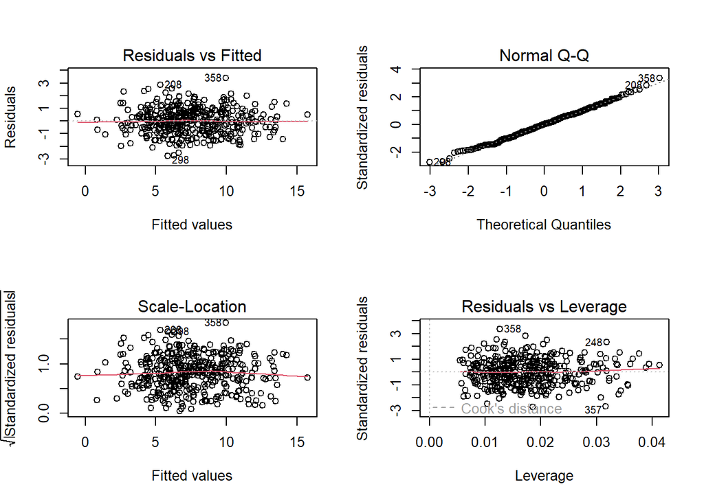

```r
par(mfrow = c(2,2))
plot(mlr.fit4)
```

Im Q-Q Plot wird bestätigt, dass es sich um ein lineares Modell handelt. Der erste Plot und das folgende Histogram bestätigen ebenfalls, dass die Residuen normalverteilt und einen Mittelwert von 0 aufweisen.

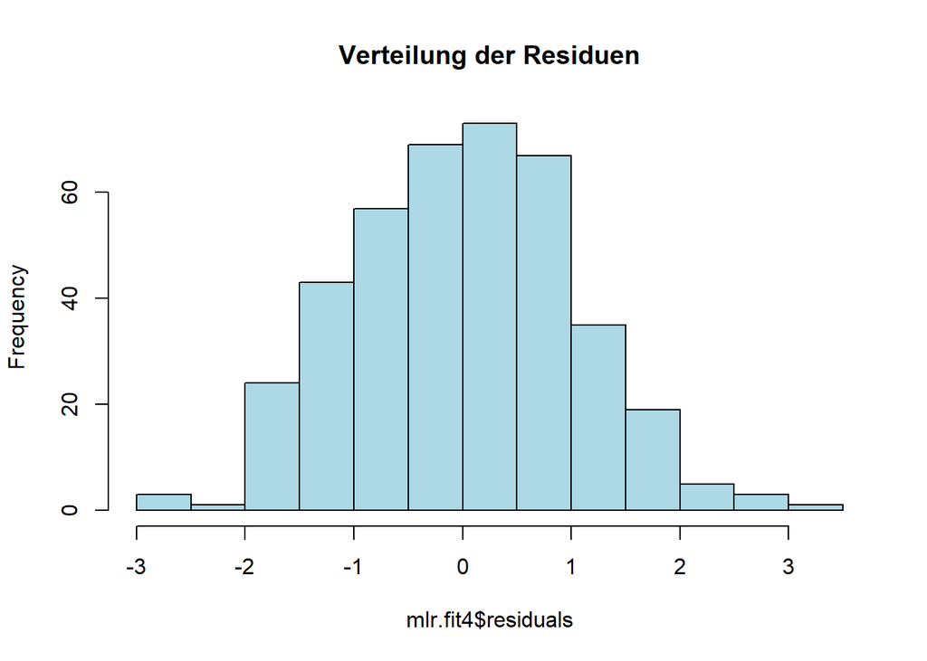

```r
hist(mlr.fit4$residuals,
     main = "Verteilung der Residuen", col = "lightblue")
```

## Interpreation von Hypothese 3

Hypothese: Sales lässt sich durch die Verwendung von mehreren Features zuverlässiger vorhersagen.

Unser letztes Modell hat gezeigt, dass mit einer sorgfältigne Auswahl der Variabeln Sales gut und zuverlässig erklärt werden kann. In der Praxis könnten noch mehr Kombinationen (Variabeln, Interaktionen, exponentielle Zusammenhänge etc…) untersucht werden. In dieser Abgabe lassen wir das weg, weil es sich lediglich um Wiederholungen der gezeigten Funktionen handelt.

# Hypothese 4: Bewohner von urbanen Regionen kaufen weniger Kindersitze als Bürger ländlicher Regionen.

Thema: Logistische Regression

## Sales vs. Urban

### Klassifizierung erstellen

Um logistische Regressionen durchzuführen, benötigen wir binäre Variabeln. Im ersten Schritt ersetzen wir Yes/No von Urban durch 1/0.

```r
Carseats <- Carseats %>%
  mutate(Urban_binaer = recode(Urban, "No" = 0, "Yes" = 1))
```

### Visualisierung von Sales und Urban

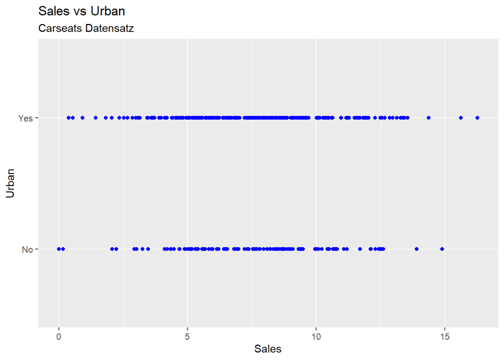

```r
ggplot(Carseats, aes(x=Sales, y=Urban)) +
  geom_point(color = "blue") +
  labs(x = "Sales",
       y = "Urban",
       title = "Sales vs Urban",
       subtitle = "Carseats Datensatz")
```

Da wir in den Plots zur logistischen Regression die Sigmoid Funktion einzeichnen möchten, verwenden wir diese Darstellung bei sämtliche logistischen Regression.

### Model erstellen und Auswertung

```r
logreg.fit1 <- glm(Urban_binaer ~ Sales, data = Carseats , family = binomial)
summary(logreg.fit1)
```

```
##
## Call:
## glm(formula = Urban_binaer ~ Sales, family = binomial, data = Carseats)
##
## Deviance Residuals:
##     Min       1Q   Median       3Q      Max
## -1.6032  -1.5464   0.8288   0.8396   0.8737
##
## Coefficients:
##             Estimate Std. Error z value Pr(>|z|)
## (Intercept)  0.96122    0.31250   3.076   0.0021 **
## Sales       -0.01197    0.03883  -0.308   0.7578
## ---
## Signif. codes:  0 '***' 0.001 '**' 0.01 '*' 0.05 '.' 0.1 ' ' 1
##
## (Dispersion parameter for binomial family taken to be 1)
##
##     Null deviance: 485.25  on 399  degrees of freedom
## Residual deviance: 485.16  on 398  degrees of freedom
## AIC: 489.16
##
## Number of Fisher Scoring iterations: 4
```

Wie wir aufgrund der Visualisierung erkannt haben, ergibt ein logistishes Regressionsmodell einen grossen P>|z| Wert. Somit gibt es keinen logistischen Zusammenhang zwischen Sales und Urban.

Gegenüber der lineare Regression haben wir den Parameter “family = binomial” erfasst.

## Sales vs. ShelveLoc

Um ein Beispiel für eine logistische Regression zeigen zu können, untersuchen wir auch Sales und ShelveLoc

### Visualisierung von Sales und ShelveLoc

Zuerst für alles ShelveLoc, danach haben die Location “Medium” entfernt.

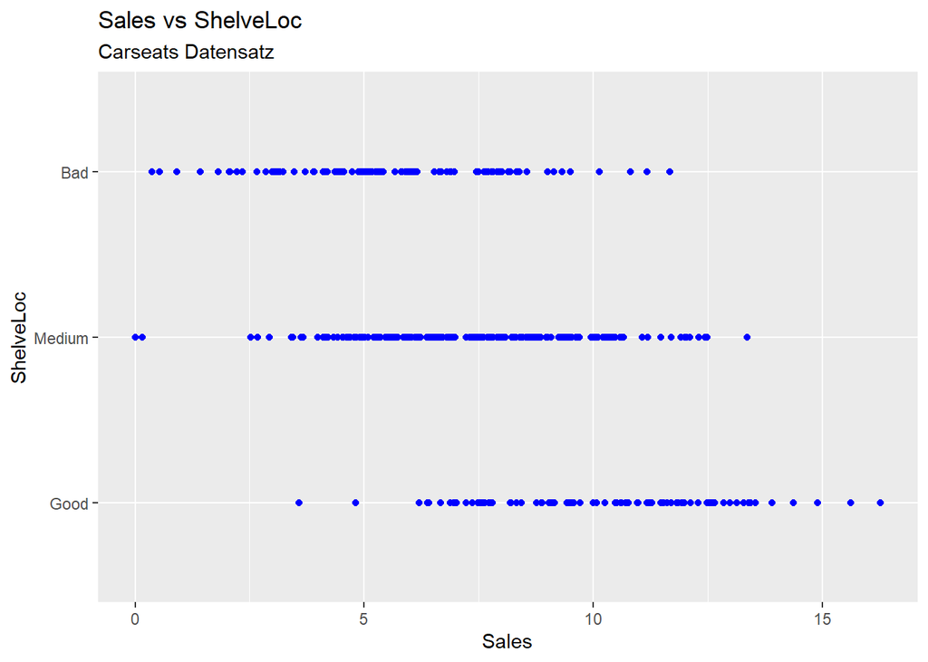

```r
Carseats %>%
  ggplot(aes(x = Sales, y = ShelveLoc)) +
  geom_point(color = "blue") +
  labs(x = "Sales",
       y = "ShelveLoc",
       title = "Sales vs ShelveLoc",
       subtitle = "Carseats Datensatz")
```

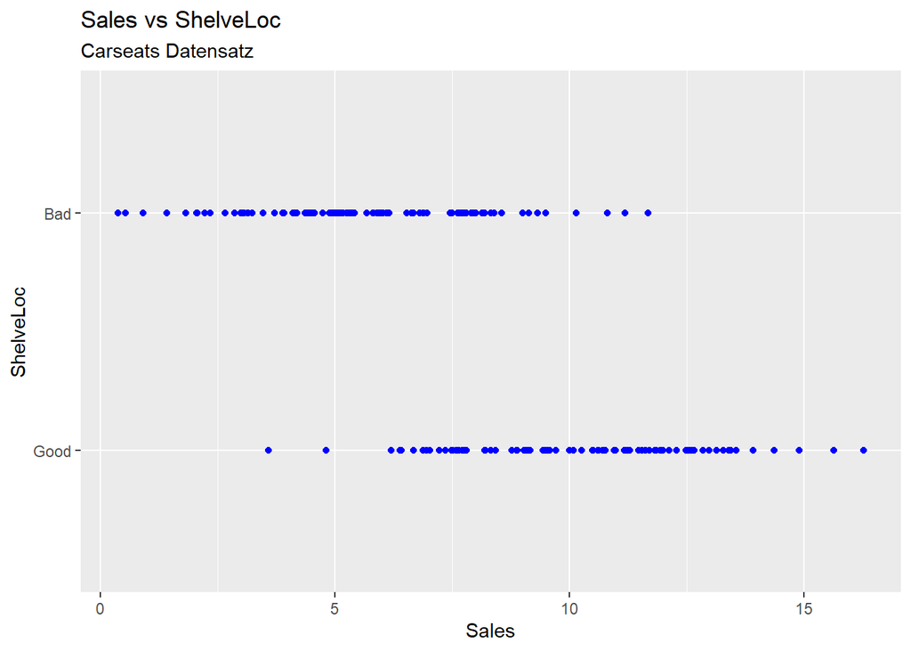

```r
Carseats_ex_medium <- Carseats %>% filter(ShelveLoc != "Medium")

Carseats_ex_medium %>%
  ggplot(aes(x = Sales, y = ShelveLoc)) +
  geom_point(color = "blue") +
  labs(x = "Sales",
       y = "ShelveLoc",
       title = "Sales vs ShelveLoc",
       subtitle = "Carseats Datensatz")
```

Im ersten Plot wurde drei Variabeln dargestellt. Für ein gutes Vorzeigebeispiel werden wir nur Good und Bad berücksichtigen.

### Klassifizierung erstellen

```r
Carseats_ex_medium <- Carseats_ex_medium %>%
  mutate(ShelveLoc_binaer = recode(ShelveLoc, "Bad" = 0, "Good" = 1))
head(Carseats_ex_medium)
```

```
##    Sales Price CompPrice Advertising ShelveLoc Urban  US Population Income Age
## 1   9.50   120       138          11       Bad   Yes Yes        276     73  42
## 2  11.22    83       111          16      Good   Yes Yes        260     48  65
## 5   4.15   128       141           3       Bad   Yes  No        340     64  38
## 6  10.81    72       124          13       Bad    No Yes        501    113  78
## 8  11.85   120       136          15      Good   Yes Yes        425     81  67
## 11  9.01   100       121           9       Bad    No Yes        150     78  26
##    Education DiffPrice Urban_binaer ShelveLoc_binaer
## 1         17       -18            1                0
## 2         10       -28            1                1
## 5         13       -13            1                0
## 6         16       -52            0                0
## 8         10       -16            1                1
## 11        10       -21            0                0
```

Wir haben “Medium” weggelassen und wieder eine binäre Klassifizierung erstellt.

### Model erstellen und Auswertung

```r
logreg.fit2 <- glm(ShelveLoc_binaer ~ Sales, data = Carseats_ex_medium , family = binomial)
summary(logreg.fit2)
```

```
##
## Call:
## glm(formula = ShelveLoc_binaer ~ Sales, family = binomial, data = Carseats_ex_medium)
##
## Deviance Residuals:
##     Min       1Q   Median       3Q      Max
## -2.3930  -0.5021  -0.1506   0.5015   2.5892
##
## Coefficients:
##             Estimate Std. Error z value Pr(>|z|)
## (Intercept)  -6.0248     0.8714  -6.914 4.71e-12 ***
## Sales         0.7566     0.1082   6.990 2.76e-12 ***
## ---
## Signif. codes:  0 '***' 0.001 '**' 0.01 '*' 0.05 '.' 0.1 ' ' 1
##
## (Dispersion parameter for binomial family taken to be 1)
##
##     Null deviance: 250.25  on 180  degrees of freedom
## Residual deviance: 136.49  on 179  degrees of freedom
## AIC: 140.49
##
## Number of Fisher Scoring iterations: 5
```

Der sehr tiefe P-Wert weist auf eine hohe Zuverlässigkeit vom Modell hin.

Im folgenden Plot wird ersichtlich, dass das Modell bei allen Läden mit Sales > 7.96 den ShelveLoc als Good klassifiziert. Die Berechnung des Wertes haben wir im folgenden Code Chunk auskommentiert.

### Visualisierung der Daten mit dem Regressions Modell

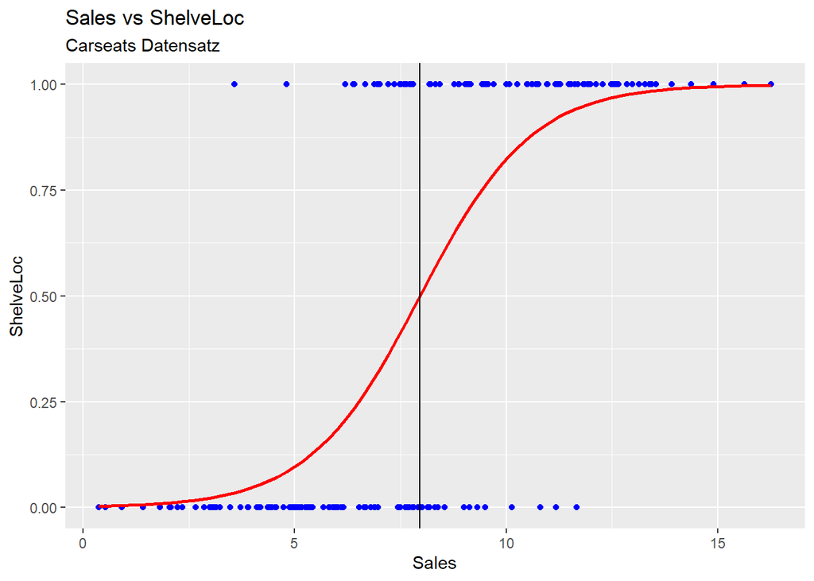

```r
ggplot(Carseats_ex_medium, aes(x=Sales, y=ShelveLoc_binaer)) +
  geom_point(color = "blue") +
  labs(x = "Sales",
       y = "ShelveLoc",
       title = "Sales vs ShelveLoc",
       subtitle = "Carseats Datensatz") +
  stat_smooth(method="glm", formula = y ~ x, color="red",
              se = FALSE, method.args = list(family=binomial)) +
  geom_vline(xintercept = 7.9633)
```

```r
# Berechnung der Decision Boundary
#-logreg.fit2$coefficients[1] / logreg.fit2$coefficients[2]
```

### Evaluierung vom logistischen Model mittels Confusions Matrix

Um die Genauigkeit des Modelles zu berechnen, erstellen wir eine Confusion Matrix.

#### Confusion Matrix erstellen

```r
# zuerst erstellen wir eine Prediction, mit den Testdaten

# Predicte ShelveLoc_binaer Werte
logreg.fit2.probs <- predict(logreg.fit2, type = "response")

# Erstellt einen Vektor mit 181  Null Werten
logreg.fit2.pred <- rep(0, 181)

# Uebreschreibt alle Werte die groesser sind als 0.5 als 1
logreg.fit2.pred[logreg.fit2.probs > .5] = 1

# Erstellen eine Kreuztabelle (Confusions Matrix)
table("Actual Class" = Carseats_ex_medium$ShelveLoc_binaer, "Predicted Class" = logreg.fit2.pred)
```

```
##             Predicted Class
## Actual Class  0  1
##            0 82 14
##            1 19 66
```

#### Confusion Matrix Performenz Kennzahlen

##### Accuracy

Die Accuracy entspricht dem Anteil korrekter Prognosen an allen Prognosen.

```r
# Accuracy Berechnen
acc <- (82 + 66) / (82 + 19 + 14 + 66)
acc
```

```
## [1] 0.8176796
```

##### Precision

Precision = True Positiv / (True Positiv + False Positiv) Preicision ist, Anteil richtig positiv an allen Positiv

Precision entspricht der Anteil korrekter positiven/1 Prognosen an allen positiven Prognosen.

```r
# Precision Berechnen
precision <- 66 / (66 + 14)
precision
```

```
## [1] 0.825
```

##### Recall / Sensitivity

Recall / Sensitivity entspricht der Anteil korrekter positiven/1 Prognosen an allen tatsächlich positiven Werten.

```r
# Recall berechnen
recall <- 66 / (66 + 19)
recall
```

```
## [1] 0.7764706
```

# Zusammenfassung

Mit unseren verwendeten Modellen konnten wir aufzeigen, dass Sales nicht von einzelnen Variabeln, aber von mehreren zusammenhängt. Dank der multiplen linearen Regression konnten wir zuverlässigen Einflussfaktoren aufzeigen.

Dank der logistischen Regression konnten wir darstellen, dass Urban keinen Einfluss hat. Mit dem Weglassen von Medium konnten wir für ShelveLoc ein zuverlässiges Modell erstellen.